# Using Chromosome Bands as Categories

D. Sarkar, S. Falcon, R. Gentleman and Kemmy MO Jones

Chromosome Bands Vignette translation from Sweave to R Markdown / HTML

March 31, 2023

#### Package

Category 2.65.0

# 1 Chromosome bands

Typically, in higher organisms, each chromosome has a centromere and two arms. The short arm is called the p arm and the longer arm the q arm. Chromosome bands (see Figure 1) are identified by differential staining, usually with Giemsa-based stains, and many disease-related defects have been mapped to these bands; such mappings have played an important role in classical cytogenetics. With the availability of complete sequences for several genomes, there have been efforts to link these bands with specific sequence locations (Furey and Haussler 2003). The estimated location of the bands in the reference genomes can be obtained from the UCSC genome browser, and data linking genes to particular bands can be obtained from a variety of sources such as the NCBI. This vignette demonstrates tools that allow the use of categories derived from chromosome bands, that is, the relevant categories are determined *a priori* by a mapping of genes to chromosome bands.

```r
library("Category")
library("ALL")
library("hgu95av2.db")
library("annotate")
library("genefilter")
##library("SNPchip")
library("karyoploteR")
library("geneplotter")
library("limma")
library("lattice")
library("graph")
```

# 2 Data Preparation

For illustration, we use a microarray dataset (Chiaretti et al. 2005) from a clinical trial in acute lymphoblastic leukemia (ALL). The data are described in Chapter 2 of (Hahne et al. 2008).

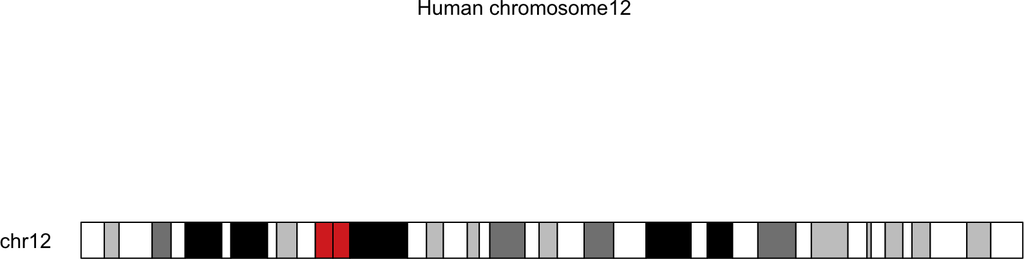

For the analysis presented here, we consider the comparison of two subsets: patients identified as having a BCR/ABL gene fusion present, typically as a result of a translocation of chromosomes 9 and 22 (labeled BCR/ABL), and those that have no observed cytogenetic abnormalities (labeled NEG). The full dataset is available in the ALL package, and the relevant subset of the data can be obtained by

```r
data(ALL, package="ALL")
subsetType <- "BCR/ABL"
Bcell <- grep("^B", as.character(ALL$BT) )
bcrAblOrNegIdx <- which(as.character(ALL$mol.biol) %in% c("NEG", subsetType) )
bcrAblOrNeg <- ALL [, intersect(Bcell, bcrAblOrNegIdx) ]
bcrAblOrNeg$mol.biol <- factor(bcrAblOrNeg$mol.biol)
```

We also create relevant annotation maps to go from feature names to Entrez ID, gene symbol, and chromosome band.

```r
annType <- c("db", "env")
entrezMap <- getAnnMap("ENTREZID", annotation(bcrAblOrNeg),
                       type=annType, load=TRUE)
symbolMap <- getAnnMap("SYMBOL", annotation(bcrAblOrNeg),
                       type=annType, load=TRUE)
bandMap <- getAnnMap("MAP", annotation(bcrAblOrNeg),
                     type=annType, load=TRUE)
```

We applied a non-specific filter to the dataset to remove probesets lacking the desired annotation as well as those with an interquartile range (IQR) below the median IQR, as probesets with little variation across samples are uninformative. We also ensured that each Entrez Gene identifier maps to exactly one probeset by selecting the probeset with the largest IQR when two or more probesets map to the same Entrez Gene ID.

```r
filterAns <- nsFilter(bcrAblOrNeg,
                      require.entrez = TRUE,
                      remove.dupEntrez = TRUE,
                      var.func = IQR, var.cutoff = 0.5)
nsFiltered <- filterAns$eset
```

We also remove probesets with no gene symbol, as well as those with no mapping to a chromosome band.

```r
hasSYM <- sapply(mget(featureNames(nsFiltered), symbolMap, ifnotfound=NA),
                 function(x) length(x) > 0 && !is.na(x[1] ) )
hasMAP <- sapply(mget(featureNames(nsFiltered), bandMap, ifnotfound=NA),
                 function(x) length(x) > 0 && !is.na(x[1] ) )
nsFiltered <- nsFiltered[hasSYM & hasMAP, ]
```

We define the *gene universe* to be the subset of genes that remain after this filtering.

```r
affyUniverse <- featureNames(nsFiltered)
entrezUniverse <- unlist(mget(affyUniverse, entrezMap))
names(affyUniverse) <- entrezUniverse
if (any(duplicated(entrezUniverse)))
    stop("error in gene universe: can't have duplicate Entrez Gene Ids")
```

We assessed differential expression between the BCR/ABL and NEG groups using an empirical Bayes approach, as implemented in the software package limma (Smyth 2005), yielding an attenuated$t$-statistic for each gene.

```r
design <- model.matrix(~ 0 + nsFiltered$mol.biol)
colnames(design) <- c("BCR/ABL", "NEG")
contr <- c(1, -1)   ## NOTE: we thus have BCR/ABL w.r.t NEG
fm1 <- lmFit(nsFiltered, design)
fm2 <-contrasts.fit(fm1, contr)
fm3 <- eBayes(fm2)
ttestLimma <- topTable(fm3, number = nrow(fm3), adjust.method = "none")
ttestLimma <- ttestLimma [featureNames(nsFiltered), ]
tstats <- ttestLimma$t
names(tstats) <- entrezUniverse [rownames(ttestLimma)]
##
```

We used a $p$-value cutoff of $0.01$ to identify a list of potentially differentially expressed genes.

```r
ttestCutoff <- 0.01
smPV <- ttestLimma$P.Value < ttestCutoff
pvalFiltered <- nsFiltered [smPV, ]
selectedEntrezIds <- unlist(mget(featureNames(pvalFiltered), entrezMap))
##
```

# 3 Methods

There are two important features of gene sets based on chromosome bands: (1) the bands are nested hierarchically, and (2) they almost form a partition (for most species almost all genes appear in only one location in the genome). This naturally leads to two different dichotomies in approaches to testing: one is a top-down versus a bottom-up approach, and the other contrasts local tests with global tests. We use human chromosome 12 as an example to describe these approaches. Users will need to identify which of the approaches best align with their objectives and then make use of the software appropriately.

Conceptually one can start a sequential testing approach either at the most coarse level of organization (probably the level of the arm: p or q), or the most specific level (that of sub-sub-bands). In the top-down approach, one first tests the hypothesis of interest on a coarse level of organization, and if rejected, the next level of organization is considered. For example, we might first consider the band 12q21, and if that hypothesis is rejected, test each of the sub-bands 12q21.1, 12q21.2, and 12q21.3. If the hypothesis for 12q21.3 is rejected, then we may subsequently examine each of 12q21.31, 12q21.32, and 12q21.33.

The bottom-up approach differs in that we begin at the most granular level and move upward, amalgamating adjacent bands at each level. The bottom-up approach is easier to put into a conditional hypothesis testing framework. Our initial null hypotheses involve the smallest, or most granular bands, and if there is evidence that these are unusual (i.e., we reject the null hypothesis) then moving to a larger, or less granular, band requires additional information to declare it significant, over and above what we have used to identify the smaller band. In our example, we would first test 12q21.31, 12q21.32, and 12q21.33, and then move up and test 12q21.3. If one or more of the three sub-bands had been declared significant, we would exclude the evidence from genes annotated in those sub-bands when testing the coarser band.

It is important to note that the top-down versus bottom-up approaches represent a fundamental trade-off between false positive and false negative errors. The bottom-up approach necessarily involves performing a larger number of tests, yielding a correspondingly larger absolute number of false positives for a given false positive rate at which each individual test is controlled. The top-down approach cuts down on the number of false positives by starting with fewer top-level tests, and performing further tests at sub-levels only when a top-level test is rejected. The disadvantage to this approach is loss of power to detect real departures that are localized to a sub-level, a phenomenon commonly illustrated using Simpson’s paradox (see, e.g., Wagner 1982).

Whether a test is local or global is a different question, orthogonal to that of top-down or bottom-up. There are two distinct but potentially relevant questions that may be of interest. The first is whether genes in a particular gene set are “different” relative to all other genes under consideration. For a Hypergeometric test, this question may be formalized as whether the proportion of interesting genes in 12q21 is different from the proportion of interesting genes in the rest of the genome, or equivalently, whether membership in 12q21 is independent of being selected. Such tests are *global* in the sense that all genes in the gene universe are used to determine whether or not genes at a location are unusual or not. An alternative is to ask whether genes in a genomic location are different relative to other genes in some meaningfully defined neighbourhood. Such a test can be performed simply by restricting the gene universe to a suitable subset; for example, when testing 12q21, we may only consider genes in 12q. A more natural approach is to use a $2 \times 3$ contingency table to test the hypothesis that the proportion of interesting genes is the same in 12q21, 12q22, and 12q23. Both these tests are *local* in the sense that only nearby genes are used.

Contingency table tests are inherently local and although they do not naturally extend to conditional testing, we can use a top-down approach to test at various resolutions. Such tests can be performed by the `cb_contingency()` function, which we do not discuss in this vignette. Instead, we focus on the bottom-up approach, which allows for conditional testing.

# 4 Utility functions

We first define a few utility functions that we subsequently use in presentation. The `chrSortOrder()` function reorders rows of data frame for display in a natural order.

```r
chrSortOrder <- function(df) {
      chrs <- sub("([^pq]+).*$", "\\1", rownames(df))
      xyIdx <- chrs %in% c("X", "Y")
      xydf <- NULL
      if (any(xyIdx)) {
          chrs <- chrs[!xyIdx]
          xydf <- df[xyIdx, ]
          df <- df[!xyIdx, ]
   }
    ord <- order(as.integer(chrs), rownames(df))
    df <- df[ord, ]
    if (!is.null(xydf))
      df <- rbind(df, xydf)
    df
 }
```

The `gseaTstatStripplot()` function creates a comparative strip plot of the $t$-statistics for specified bands.

```r
gseaTstatStripplot <- function(bands, g, ..., include.all = FALSE) {
     chroms <- c(1:22, "X", "Y")
     chromArms <- c(paste(chroms, "p", sep=""), paste(chroms, "q", sep=""))
     egid <- lapply(nodeData(g, bands), "[[", "geneIds")
     if (include.all) {
       egid$All <-
         unique(unlist(lapply(nodeData(g)[chromArms], "[[","geneIds")))
   }
     tdf <- do.call(make.groups, lapply(egid, function(x) tstats[x]))
     stripplot(which ~ data, tdf, jitter = TRUE, ...)
}
```

The `esetBWPlot()` function creates box-and-whisker plots for every gene in an *“ExpressionSet”*.

```r
esetBWPlot <- function(tmpSet, ..., layout=c(1, nrow(emat)))
{
  emat <- exprs(tmpSet)
  pd <- pData(tmpSet)
  probes <- rownames(emat)
  syms  <-
        sapply(mget(probes, hgu95av2SYMBOL, ifnotfound=NA),
               function(x) if (all(is.na(x))) "NA" else as.character(x)[1])
  selectedAffy <-
        probes %in% affyUniverse[selectedEntrezIds]
  symsSelected <- syms[selectedAffy]
  symsWithStatus <-
      paste(syms,
            ifelse(selectedAffy, "*",""),
            sep = "")
  pdat <-
       cbind(exprs=as.vector(emat),
             genes=factor(probes, levels = probes, labels = syms),
             pd[rep(seq_len(nrow(pd)), each=nrow(emat)), ])
  pdat <- transform(pdat, genes = reorder(genes, exprs))
  panels.to.shade <- levels(pdat$genes) %in% symsSelected
  bwplot(mol.biol ~ exprs | genes, data=pdat,
         layout = layout,
         auto.key=TRUE,
         scales=list(x=list(log=2L)),
         xlab="Log2 Expression",
         panels.to.shade = panels.to.shade,
         panel = function(..., panels.to.shade) {
             if(panels.to.shade[packet.number()])
               panel.fill(col = "lightgrey")
             panel.bwplot(...)
             },
             strip=FALSE,
             strip.left=TRUE, ...)
  }
g1 <- makeChrBandGraph(annotation(nsFiltered), univ=entrezUniverse)
ct <- ChrBandTreeFromGraph(g1)
subsetByBand <- function(eset, ct, band) {
  egIDs <- unlist(nodeData(ct@toChildGraph, n=band,
                           attr="geneIds"), use.names=FALSE)
  wantedProbes <- affyUniverse[as.character(egIDs)]
  eset[intersect(wantedProbes, featureNames(eset)), ]
}
```

# 5 Hypergeometric Testing

We use a method similar to that described in Falcon and Gentleman (2007) to conditionally test for over-representation of chromosome bands in the selected gene list. A test is set up by creating a suitable object of class *“ChrMapHyperGParams”*. We first create an object to perform a standard Hypergeometric analysis, treating each chromosome band independently, and then modify a copy to represent a conditional Hypergeometric computation.

```r
params <- new("ChrMapHyperGParams",
              conditional=FALSE,
              testDirection="over",
              universeGeneIds=entrezUniverse,
              geneIds=selectedEntrezIds,
              annotation="hgu95av2",
              pvalueCutoff=0.05)
paramsCond <- params
paramsCond@conditional <- TRUE
```

The test computations are performed by

```r
hgans <- hyperGTest(params)
hgansCond <- hyperGTest(paramsCond)
```

The results can be summarized by

```r
sumUn <- summary(hgans, categorySize=1)
chrSortOrder(sumUn)
```

```
##    ChrMapID       Pvalue OddsRatio   ExpCount Count Size
## 1   14q22.2 0.0005784156 22.692958  0.4907724     4    6
## 2    7q31.2 0.0047908084 16.971910  0.4089770     3    5
## 3    9q21.1 0.0062117150  7.556808  0.8179540     4   10
## 4     13q31 0.0066733711       Inf  0.1635908     2    2
## 5   13q31.1 0.0066733711       Inf  0.1635908     2    2
## 6      6p23 0.0066733711       Inf  0.1635908     2    2
## 7    9q33.2 0.0090032012 11.311798  0.4907724     3    6
## 8    2p22.2 0.0148085762  8.481742  0.5725678     3    7
## 9  12q21.33 0.0189339982 22.571429  0.2453862     2    3
## 10   2q31.3 0.0189339982 22.571429  0.2453862     2    3
## 11   4q22.1 0.0189339982 22.571429  0.2453862     2    3
## 12    14q22 0.0197575131  3.780603  1.6359080     5   20
## 13    12q14 0.0222758094  6.783708  0.6543632     3    8
## 14      6q2 0.0229391129  2.164685  5.6438824    11   69
## 15  12q21.3 0.0358280017 11.282913  0.3271816     2    4
## 16     4q22 0.0358280017 11.282913  0.3271816     2    4
## 17 10p11.22 0.0358280017 11.282913  0.3271816     2    4
## 18 12q13.11 0.0358280017 11.282913  0.3271816     2    4
## 19   6q24.2 0.0358280017 11.282913  0.3271816     2    4
## 20        9 0.0419943288  1.624759 12.5146958    19  153
## 21     1p21 0.0422279373  4.843098  0.8179540     3   10
## 22    20p12 0.0422279373  4.843098  0.8179540     3   10
## 23 22q11.23 0.0422279373  4.843098  0.8179540     3   10
## 24       6q 0.0439995864  1.808967  7.7705628    13   95
## 25  1p36.11 0.0446151403  3.481690  1.3905218     4   17
```

```r
sumCond <- summary(hgansCond, categorySize=1)
chrSortOrder(sumCond)
```

```
##    ChrMapID       Pvalue OddsRatio   ExpCount Count Size
## 1   14q22.2 0.0005784156 22.692958  0.4907724     4    6
## 2    7q31.2 0.0047908084 16.971910  0.4089770     3    5
## 3    9q21.1 0.0062117150  7.556808  0.8179540     4   10
## 4   13q31.1 0.0066733711       Inf  0.1635908     2    2
## 5      6p23 0.0066733711       Inf  0.1635908     2    2
## 6    9q33.2 0.0090032012 11.311798  0.4907724     3    6
## 7    2p22.2 0.0148085762  8.481742  0.5725678     3    7
## 8  12q21.33 0.0189339982 22.571429  0.2453862     2    3
## 9    2q31.3 0.0189339982 22.571429  0.2453862     2    3
## 10   4q22.1 0.0189339982 22.571429  0.2453862     2    3
## 11    12q14 0.0222758094  6.783708  0.6543632     3    8
## 12      6q2 0.0229391129  2.164685  5.6438824    11   69
## 13 10p11.22 0.0358280017 11.282913  0.3271816     2    4
## 14 12q13.11 0.0358280017 11.282913  0.3271816     2    4
## 15   6q24.2 0.0358280017 11.282913  0.3271816     2    4
## 16        9 0.0419943288  1.624759 12.5146958    19  153
## 17     1p21 0.0422279373  4.843098  0.8179540     3   10
## 18    20p12 0.0422279373  4.843098  0.8179540     3   10
## 19 22q11.23 0.0422279373  4.843098  0.8179540     3   10
## 20  1p36.11 0.0446151403  3.481690  1.3905218     4   17
```

For the standard test, the structure of the chromosome band graph is ignored and a Hypergeometric test is applied to each band independently. For the conditional test, the hierarchical relationship among the bands as represented by the graph is used in the computation. The highest-resolution bands (those with no children in the graph) are tested first. Testing proceeds with the bands whose children (sub-bands) have already been tested. For these bands, the gene annotations that are inherited from significant child nodes (children with $p$-value smaller than the specified cutoff) are removed prior to testing to yield a conditional test.

The effect of the conditional test is illustrated by examining the results for 14q and its sub-bands. In the standard test, we see that 14q22 and 14q22.2 both have a significant $p$-value. In the conditional test, only 14q22.2 remains. The conclusion is that there is not enough additional evidence beyond that provided by 14q22.2 to mark 14q22 as significant.

# 6 GSEA using linear models

GSEA is a popular method that can be used to assess whether or not particular gene sets are associated with a phenotype of interest (Subramanian et al. 2005; Tian et al. 2005; Jiang and Gentleman 2007). Most applications of this method do not explicitly deal with structure of the gene sets, but when analyzing chromosomal location such methods are desirable. We present a simple approach that is similar in spirit to traditional GSEA, and generalizes nicely to accommodate nested categories. Consider the situation where gene $i$ has an associated measure of differential expression $y_i$; for example, an attenuated $t$-statistic derived from a differential expression analysis such as limma (Smyth 2005). Given a particular category, GSEA asks whether the distribution of $y_i$-s restricted to the category of interest is “unusual”. Thus, in Figure 2, we might be interested in knowing whether the distribution of $y_i$ values for genes in 12q21 is different from that of the genes in 12q (for a local test) or of all genes in the gene universe (for a global test). Figure 2 is produced by

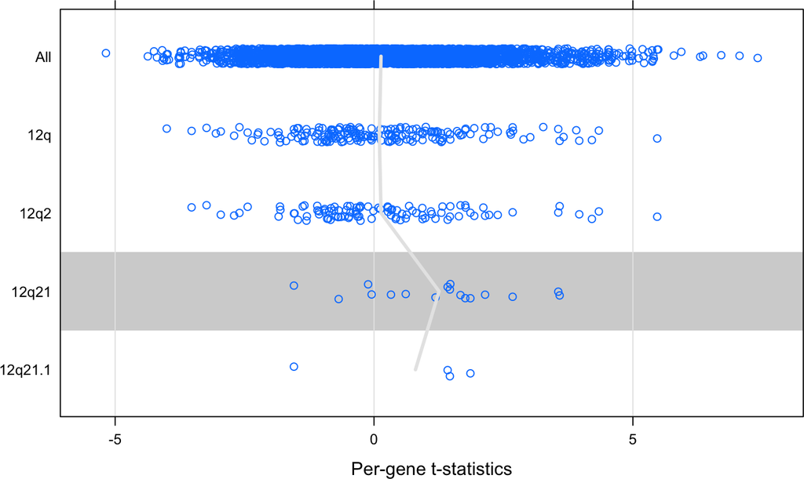

Figure 2: Per-gene *t*-statistics, as computed by limma, for selected chromosome bands. The points are jittered vertically to alleviate overlap. A thick grey line joins the mean value within each group. A GSEA test would compare the genes in 12q21 with those in 12q, or the entire gene universe, by fitting a linear model with per-gene *t*-statistics as the response, and a term indicating membership in 12q21 as the predictor. If 12q21.1 is declared as significant, a conditional GSEA test would include an additional term for 12q21.1.

```r
gseaTstatStripplot(c("12q21.1", "12q21", "12q2", "12q"),
                   include.all = TRUE,
                   g = g1,
                   xlab = "Per-gene t-statistics",
                   panel = function(...) {
                       require(grid, quietly = TRUE)
                       grid.rect(y = unit(2, "native"),
                                 height = unit(1, "native"),
                                 gp =
                                 gpar(fill = "lightgrey",
                                      col = "transparent"))
                       panel.grid(v = -1, h = 0)
                       panel.stripplot(...)
                       panel.average(..., fun = mean, lwd = 3)
                   })
```

We fit a factorial model to see whether the distribution of $y_i$ is associated with category membership. Specifically, for category $j$, we fit the model
$$\label{eq:lm1} y_i = \beta_0 + \beta_1 a_{ij} +\varepsilon_{i}$$
where $a_{ij} = 1$ if gene $i$ belongs to category $j$, and $0$ otherwise. The index $i$ may range over the full gene universe, or a subset, depending on whether one wishes to perform global or local tests. The null hypothesis of no association is represented by $H_0: \beta_1 = 0$. The model nominally assumes that the $y_i$-s are Normally distributed with equal variance, but in practice the results are robust against mild deviations. The presence of an intercept term allows nonzero overall mean, which can be important in many situations, especially for local tests. We expect the test to be fairly insensitive to distributional assumptions on the $y_i$-s.

We can fit (1) by least squares and test $H_0: \beta_1 = 0$ to obtain a marginal test for each category $j$; in this case, each chromosome band. The procedure also generalizes to incorporate the nesting structure of chromosome bands. Specifically, if band $j_2$ (e.g., 12q21.1) is nested within a coarser band $j_1$ (e.g., 12q21) and the more granular band $j_2$ is significant, then the effect of membership in $j_1$ over and above the effect attributable to membership in $j_2$ can be tested by fitting the model
$$\label{eq:lm2}
y_i = \beta_0 + \beta_1 a_{ij_1} + \beta_2 a_{ij_2} + \varepsilon_{i}$$
and testing the null hypothesis $H_0: \beta_1 = 0$. Multiple significant sub-bands and multiple levels of nesting can be incorporated by including further terms in the model. The complete process can be summarized as follows: Start by marginally testing each band which has no sub-bands. For all other bands, first test all sub-bands, then test the current band using a linear model that includes a term for each *significant* sub-band.

We apply this procedure to perform global tests using per-gene $t$-statistics as a measure of differential expression in BCR/ABL relative to NEG samples. As with the Hypergeometric tests, we start by creating objects of class *“ChrMapLinearMParams”*.

```r
params <- new("ChrMapLinearMParams",
              conditional = FALSE,
              testDirection = "up",
              universeGeneIds = entrezUniverse,
              geneStats = tstats,
              annotation = "hgu95av2",
              pvalueCutoff = 0.01,
              minSize = 4L)

params@graph <- makeChrBandGraph(params@annotation, params@universeGeneIds)
params@gsc <- makeChrBandGSC(params@graph)
paramsCond <- params
paramsCond@conditional <- TRUE
```

The tests are performed, and the results summarized by

```r
lmans <- linearMTest(params)
lmansCond <- linearMTest(paramsCond)
chrSortOrder(summary(lmans))
```

```
##      ChrMapID       Pvalue    Effect Size Conditional TestDirection
## 53      12q21 1.226213e-03 1.1250647   17       FALSE            up
## 54    12q21.3 7.675013e-03 1.8539775    4       FALSE            up
## 76         14 6.053485e-03 0.3117778  157       FALSE            up
## 77        14q 6.053485e-03 0.3117778  157       FALSE            up
## 81       14q2 2.305207e-04 0.6152527   77       FALSE            up
## 83      14q22 1.153599e-04 1.2608760   20       FALSE            up
## 98      15q21 7.864796e-03 0.8721684   18       FALSE            up
## 133       18p 1.034270e-03 0.8925126   28       FALSE            up
## 134      18p1 1.034270e-03 0.8925126   28       FALSE            up
## 135     18p11 1.034270e-03 0.8925126   28       FALSE            up
## 137   18p11.3 5.687826e-03 1.0748058   13       FALSE            up
## 161       1p2 3.768696e-03 0.7247847   32       FALSE            up
## 162      1p21 8.355225e-04 1.5208019   10       FALSE            up
## 216         2 4.064842e-04 0.3060445  300       FALSE            up
```

[output cut: 37 more lines]

```r
chrSortOrder(summary(lmansCond))
```

```
##      ChrMapID       Pvalue    Effect Size Conditional TestDirection
## 54    12q21.3 7.675013e-03 1.8539775    4        TRUE            up
## 81       14q2 7.893819e-03 0.4407200   77        TRUE            up
## 98      15q21 7.864796e-03 0.8721684   18        TRUE            up
## 137   18p11.3 5.687826e-03 1.0748058   13        TRUE            up
## 228       2q1 9.527008e-03 0.5694083   40        TRUE            up
## 240      2q33 7.529350e-03 0.9032265   17        TRUE            up
## 256        3q 6.983745e-03 0.3725591  122        TRUE            up
## 266      3q25 3.809785e-04 1.2148855   18        TRUE            up
## 271         4 5.357453e-03 0.3282355  158        TRUE            up
## 291         5 3.987179e-03 0.2940783  205        TRUE            up
## 306      5q23 3.555656e-03 1.6809836    6        TRUE            up
## 348    7q21.1 9.147762e-03 1.1422131   10        TRUE            up
## 388    9q21.1 8.243858e-04 2.4034672   10        TRUE            up
## 1042 10p11.22 8.053864e-03 1.8405737    4        TRUE            up
## 1174  14q22.2 9.092615e-06 2.6734149    6        TRUE            up
## 1205  15q24.3 8.504394e-03 1.6328169    5        TRUE            up
## 1220  16q12.1 7.610085e-03 1.4037361    7        TRUE            up
## 1254 18p11.22 1.003528e-03 1.6707653    8        TRUE            up
## 1293   1p21.3 2.500404e-03 1.7529252    6        TRUE            up
## 1503   4q13.3 8.388741e-03 1.0570420   12        TRUE            up
## 1577   6p22.3 2.989781e-03 1.1672122   13        TRUE            up
## 1594     6q21 1.292155e-03 1.1191866   17        TRUE            up
## 1598   6q23.3 3.192526e-03 1.5770967    7        TRUE            up
## 1600   6q24.2 7.434128e-03 1.8628060    4        TRUE            up
## 1631   7q31.2 4.049223e-05 2.6936729    5        TRUE            up
## 1686  9q21.13 7.571655e-04 1.9803350    6        TRUE            up
## 1700   9q33.2 3.825568e-04 2.1006502    6        TRUE            up
```

```r
##
```

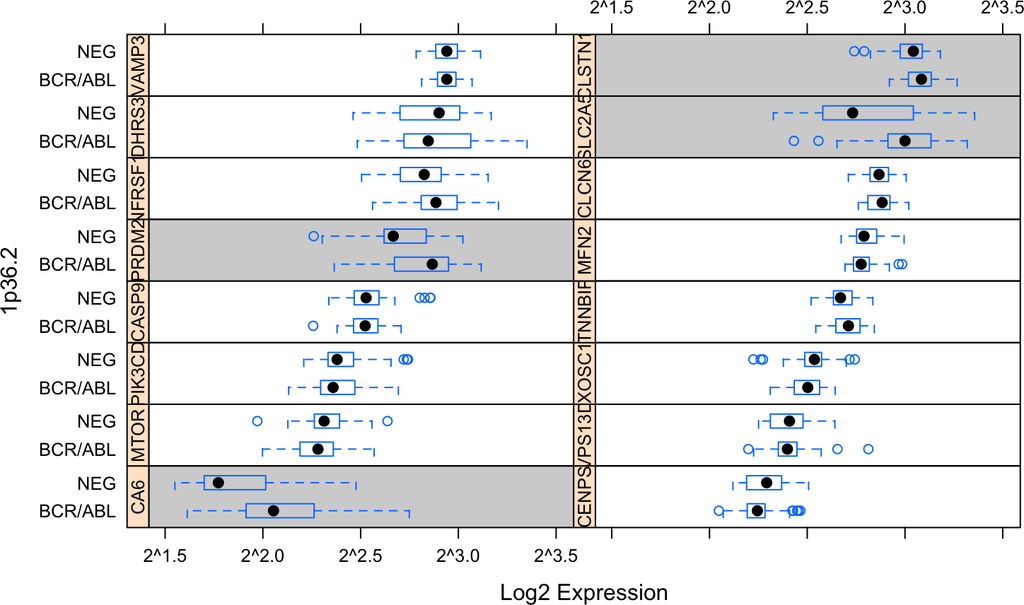

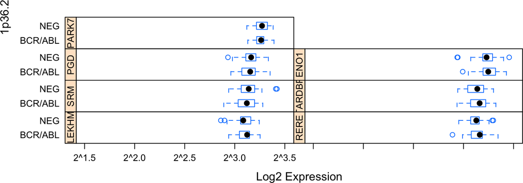

```r
tmpSet <- subsetByBand(nsFiltered, ct, "1p36.2")
esetBWPlot(tmpSet, ylab="1p36.2", layout = c(2, 8),
           par.strip.text = list(cex = 0.8))
```

# References:

Chiaretti, S., X. Li, R. Gentleman, A. Vitale, K. S. Wang, F. Mandelli, R. Foa, and J. Ritz. 2005. “Gene Expression Profiles of b-Lineage Adult Acute Lymphocytic Leukemia Reveal Genetic Patterns That Identify Lineage Derivation and Distinct Mechanisms of Transformation.” *Clinical Cancer Research* 11: 7209–19.

Falcon, S, and R Gentleman. 2007. “Using GOstats to Test Gene Lists for GO Term Association.” *Bioinformatics* 23 (2): 257–58.

Furey, T. S., and D. Haussler. 2003. “Integration of the Cytogenetic Map with the Draft Human Genome Sequence.” *Human Molecular Genetics* 12: 1037–44. DOI: 10.1093/hmg/ddg113.

Hahne, F., W. Huber, R. Gentleman, and S. Falcon. 2008. *Bioconductor Case Studies*. New York: Springer.

Jiang, Z., and R. Gentleman. 2007. “Extensions to Gene Set Enrichment.” *Bioinformatics* 23: 306–13.

Smyth, Gordon K. 2005. “Limma: Linear Models for Microarray Data.” In *Bioinformatics and Computational Biology Solutions Using r and Bioconductor*, edited by R. Gentleman, V. Carey, S. Dudoit, R. Irizarry, and W. Huber, 397–420. New York: Springer.

Subramanian, A., P. Tamayo, V. K. Mootha, et al. 2005. “Gene Set Enrichment Analysis: A Knowledge-Based Approach for Interpreting Genome-Wide Expression Profiles.” *Proceedings of the National Academy of Sciences* 102 (43): 15545–50.

Tian, L., S. A. Greenberg, S. W. Kong, et al. 2005. “Discovering Statistically Significant Pathways in Expression Profiling Studies.” *Proceedings of the National Academy of Sciences* 102 (38): 13544–49.

Wagner, Clifford H. 1982. “Simpson’s Paradox in Real Life.” *The American Statistician* 36 (1): 46–48.